# Loon in RMarkdown

R.W. Oldford

# Loon plots

Start by accessing `loon`

```r
library(loon)
```

Plots in `loon` are dynamic and interactive. Their display contents can be changed either through direct manipulation and the loon inspector, or programmatically. To interact with them programmatically (including transferring them to `grid` graphics objects), it is best to assign them to a variable at creation.

For example,

```r
p <- l_plot(x = iris$Sepal.Width, y = iris$Sepal.Length, color = iris$Species,
    xlabel = "sepal width", ylabel = "sepal length", title = "The famous Iris data",
    showGuides = TRUE)
```

## Just `plot` the `loon` plot!

This can now be printed and embedded in the document at any time using the `plot()` function as in

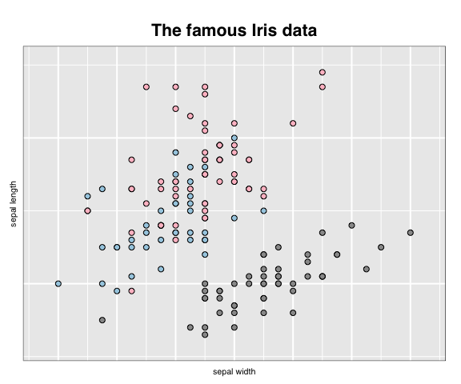

```r
gp <- plot(p)
```

```r
gp
```

```
## gTree[GRID.gTree.33]
```

In addition to displaying the plot as a `grid` graphic, the value of `plot(p)` is saved by setting it to the variable `gp`. The value is a very rich data structure (a `gtree`) which can now be used as any other `grid` graphics object (or `grob`). Note that the display could have been suppressed at this time simply as follows:

```r
gp <- plot(p, draw = FALSE)
gp
```

```
## gTree[GRID.gTree.34]
```

Either way, `gp` is a `grid` data structure that can be manipulated as any other `grob`. Try `grid::grid.ls(gp)` or in RStudio `View(gp)` to examine the full data structure.

See `plot.loon`, `grid.loon`, and `loonGrob` for more details on transferring a `loon` plot to a `grid` graphics object.

## Exporting to an image file

Being a `grid` graphics object, `gp` could also be exported to an image file of some kind using any of a variety of graphics devices (e.g. see `?png`) or perhaps via RStudio’s “Export” plot functionality (to a “png” or “pdf” format).

For example, we could save `gp` as a “.png” file by drawing it using the `png()` device and `grid.draw()` from the `grid` graphics package.

```r
png(filename = "images/loonplot1.png", width = 600, height = 500)
grid::grid.draw(gp)
dev.off()
```

The plot is now saved as a “png” file “loonplot1.png” in the “images” sub-directory of the current directory “.” (you could save it into any existing directory you choose and for which you have write privileges). Alternatively, if `gp` was not saved then `plot(p)` could have been used in place of the `grid::grid.draw(gp)` line above.

Once saved, this external image can be embedded in the document using `knitr::include_graphics()` as

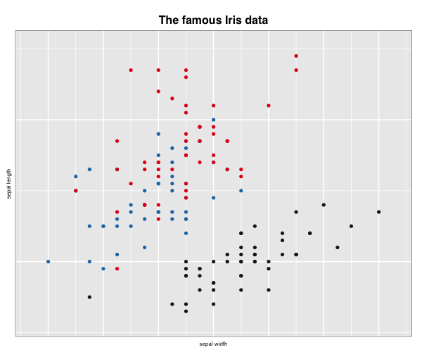

```r
knitr::include_graphics("images/loonplot1.png")
```

which will look slightly different because of the transfer of the grid graphic to “png”

Instead of `knitr`, the same result (at least for `pdf` output documents) could be produced using the command `\includegraphics` from the LaTeX package `graphicx`.

One advantage of LaTeX over `knitr` commands is the control it allows over the display, especially of multiple plots. The disadvantage is that results might vary if the output is not a “pdf” file (e.g. an “html” file).

See also the `png` package.

## Reading in previously saved states

We could also just save the relevant display states from one loon plot as an `R` data set (in an `RDS` file). This is done using the function `l_saveStatesRDS()`.

Suppose, for example, suppose the previously constructed `p` contains valuable information in its display. We could save its states (`l_info_states()`) as follows:

```r
# Having determined the colours you could save them (and other
# states) in a file of your choice, here some tempfile:
myFileName <- tempfile("myPlot", fileext = ".rds")

# We could save all of the 'usual' states (excludes certain
# 'basic' states, see help(l_saveStatesRDS))
l_saveStatesRDS(p, file = myFileName)

# Or simply save selected named states as an RDS
l_saveStatesRDS(p, states = c("color", "active", "selected"), file = myFileName)
```

Having saved the desired states (not in a temporary file as above, but in some more permanent file), they can be retrieved later and used on a new plot (say in `RMarkdown`) to set the new plot’s values to those previously determined interactively.

```r
# We have a new plot (or two)
p_new <- l_plot(iris, showGuides = TRUE)
h_new <- l_hist(iris$Sepal.Width, showBinHandle = FALSE, yshows = "density",
    showStackedColors = TRUE)

# And read the saved data back in using R's readRDS() function
p_saved_info <- readRDS(myFileName)
# which is an object of class
class(p_saved_info)
```

```
## [1] "l_savedStates"
```

```r
# The values on p_saved_info can now be all set using
# l_copyStates()
l_copyStates(source = p_saved_info, target = p_new)
```

```r
# or selectively and even from different classes of loon plots
h_new["color"] <- p_saved_info$color
```

Having assigned the saved states to the new plots, the new plots can be presented in the `Rmarkdown` document via `plot()`.

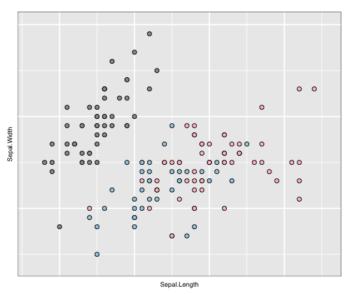

```r
plot(p_new)
```

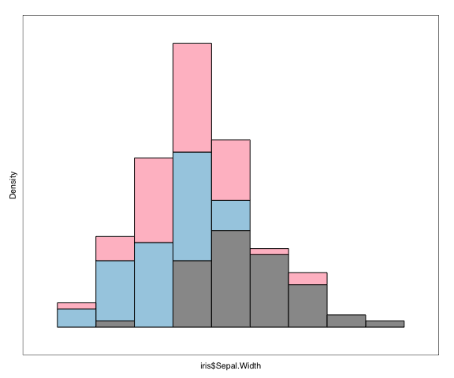

```r
plot(h_new)
```

## Multiple views of a loon plot

Sometimes, there will be changes made to a single loon plot which you would like to capture in your document.

This might have been done interactively through direct manipulation, or programmatically.

### Plots from programmatic manipulation

```r
saveTitle <- p["title"]

p["title"] <- "1. Setosa selected"
p["selected"] <- iris$Species == "setosa"
gp_select <- plot(p, draw = FALSE)

p["title"] <- "2. Scale to the selected points"
l_scaleto_selected(p)
gp_select_zoom <- plot(p, draw = FALSE)

p["title"] <- "3. Turn off selection"
p["selected"] <- FALSE
gp_setosa_zoom <- plot(p, draw = FALSE)

# Put the plot back to how it was originally
p["title"] <- saveTitle
l_scaleto_plot(p)
```

We now have three more “snapshots” of our interaction with the `loon` plot `p`.

We can now use the `gridExtra` package to arrange these in a single display.

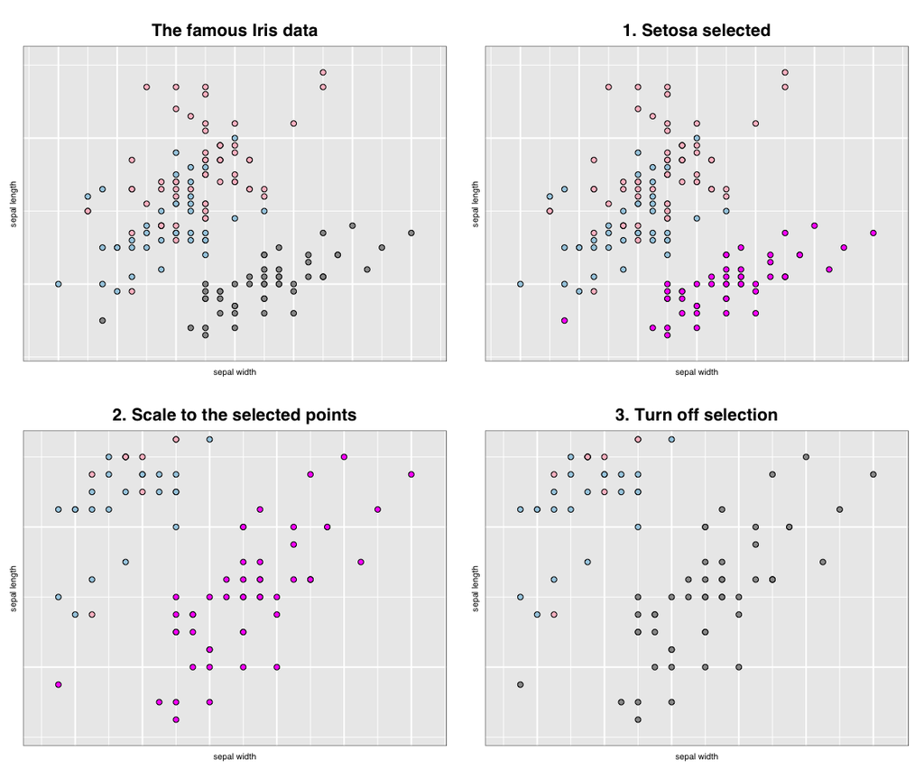

```r
library(gridExtra)
# which can now be arranged in sequence
grid.arrange(gp, gp_select, gp_select_zoom, gp_setosa_zoom)
```

### Plots from saved exported images

Alternatively, all plots might have been developed through direct manipulation.  
Any time a snapshot of the current plot is desired, it is simply turned to a `grid` object via `plot(p)` and saved as an external images (e.g. say as a `png` file) through the `png()` device, or the perhaps via RStudio’s export as “png” files. (N.B. Here we do it programmatically only to save the files.)

```r
png(filename = "images/loonplot2.png", width = 600, height = 500)
grid::grid.draw(gp_select)
dev.off()
png(filename = "images/loonplot3.png", width = 600, height = 500)
grid::grid.draw(gp_select_zoom)
dev.off()
png(filename = "images/loonplot4.png", width = 600, height = 500)
grid::grid.draw(gp_setosa_zoom)
dev.off()
```

For example, had the previous plots been saved as `"loonplot2.png"`, `"loonplot3.png"`, and `"loonplot4.png"` then `knitr` could produce them in sequence as before but now using `fig.show = "hold"` in the header for the following `R` segment:

```r
knitr::include_graphics(path = "images/loonplot1.png")
knitr::include_graphics(path = "images/loonplot2.png")
knitr::include_graphics(path = "images/loonplot3.png")
knitr::include_graphics(path = "images/loonplot4.png")
```

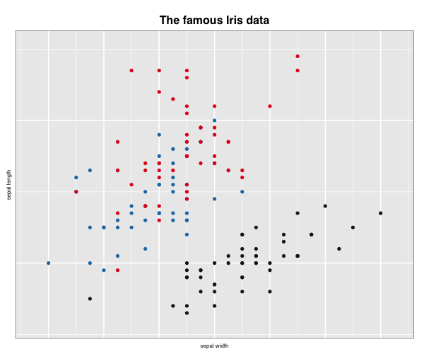

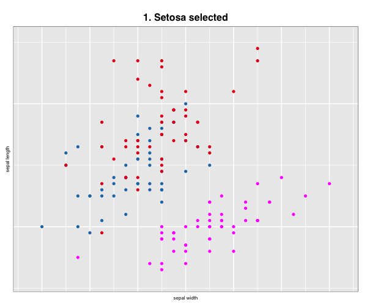

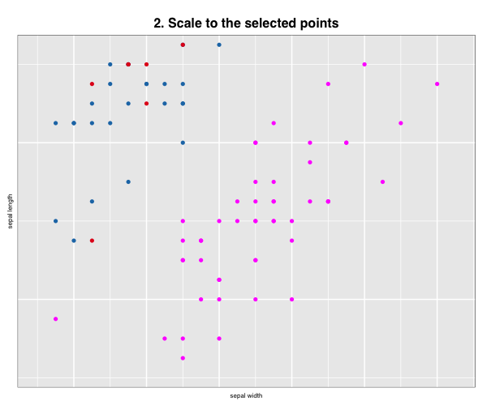

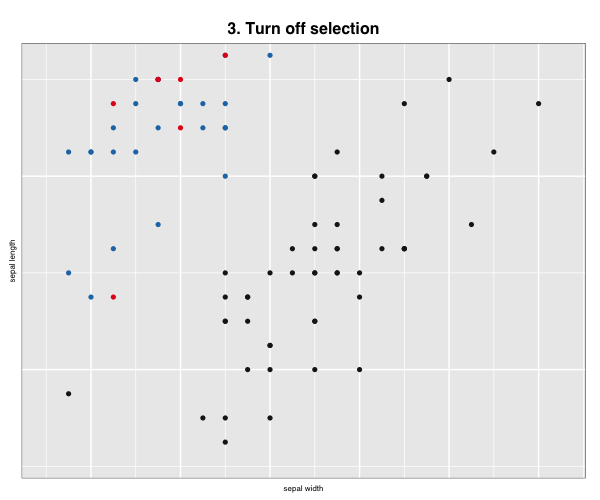

```r
knitr::include_graphics(path = path_concat(imageDirectory, "loonplot1.png"))
knitr::include_graphics(path = path_concat(imageDirectory, "loonplot2.png"))
knitr::include_graphics(path = path_concat(imageDirectory, "loonplot3.png"))
knitr::include_graphics(path = path_concat(imageDirectory, "loonplot4.png"))
```

More layout control is available using `grid` graphics functions `as.raster()` and `rasterGrob()`, the function `grid.arrange()` from the `gridExtra` package, and `readPNG()` from the `png` package.

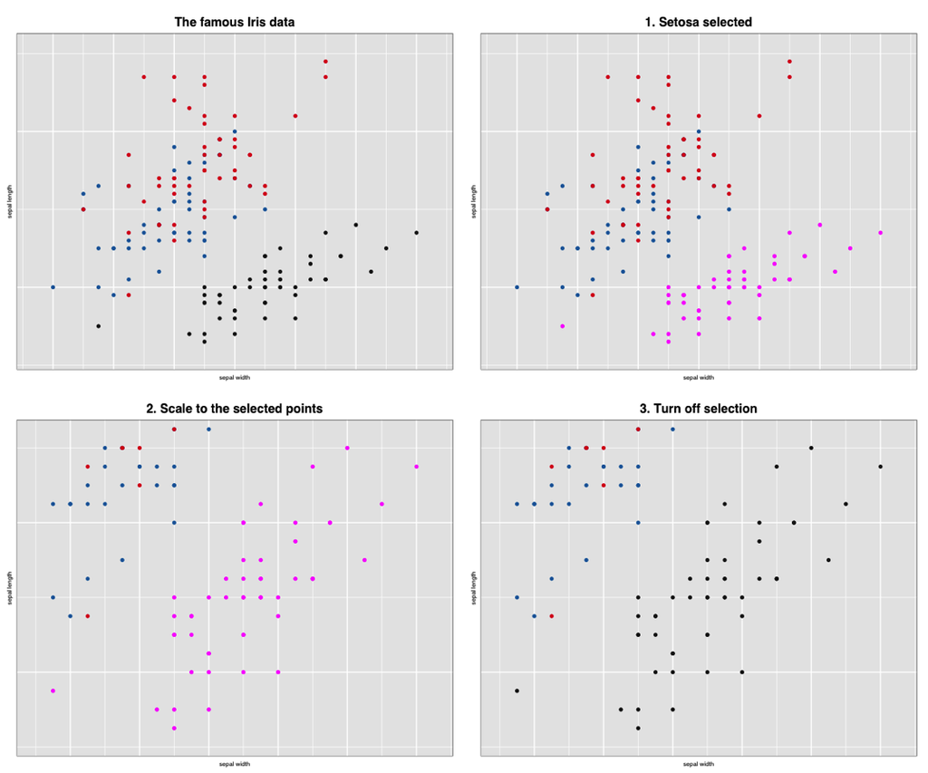

```r
library(grid)
library(gridExtra)
library(png)

img <- as.raster(readPNG(source = "images/loonplot1.png"))
gp <- rasterGrob(img)

img <- as.raster(readPNG(source = "images/loonplot2.png"))
gp_select <- rasterGrob(img)

img <- as.raster(readPNG(source = "images/loonplot3.png"))
gp_select_zoom <- rasterGrob(img)

img <- as.raster(readPNG(source = "images/loonplot4.png"))
gp_setosa_zoom <- rasterGrob(img)

grid.arrange(gp, gp_select, gp_select_zoom, gp_setosa_zoom)
```

Alternatively, LaTeX commands (like `tabular` layouts) could be used lay out the images.

See also `ggsave` in `grid`.